# Figures for ‘Food processing and pottery use in the Early Bronze Age, Central Korean Peninsula’

Ben Marwick & Seunkgi Kwak

2015-12-10

This document reproduces the figures illustrating the geochemical data in Kwak and Marwick ‘Food processing and pottery use in the Early Bronze Age, Central Korean Peninsula’

```r
library(kwakmarwick2015)
knitr::opts_chunk$set(cache = TRUE)
```

## Figures

The density distribution of the radiocarbon dates from the two sites.

```r
# read data in, three columns Name = lab code, Date = radiocarbon age, Uncertainty =  error
dates_KM <- read.csv('data/radiocarbon_KM.csv', stringsAsFactors = FALSE)
dates_SS <- read.csv('data/radiocarbon_SS.csv', stringsAsFactors = FALSE)

# make date names
dates_KM$Name <- paste0("KM_", dates_KM[,1])
dates_SS$Name <- paste0("SS_", dates_SS[,1])
# remove spaces
dates_KM$Name <- gsub("[[:space:]]", "_", dates_KM$Name)
dates_SS$Name <- gsub("[[:space:]]", "_", dates_SS$Name)

# split age and error term
library(stringr)

# KM
date_split  <- str_split_fixed(dates_KM$C14.date..BP..uncalibrated., "pm", 2)
date_split_Age <- as.numeric(gsub("[^0-9]", "", date_split[, 1]))
date_split_Error <- as.numeric(gsub("[^0-9]", "", date_split[, 2]))
# combine into data frame
dates_KM <- data.frame(Name = dates_KM$Name,
                       Date = date_split_Age,
                       Uncertainty = date_split_Error)
# SS
date_split  <- str_split_fixed(dates_SS$C14.date..BP..uncalibrated., "\\?\\?", 2)
date_split_Age <- as.numeric(gsub("[^0-9]", "", date_split[, 1]))
date_split_Error <- as.numeric(gsub("[^0-9]", "", date_split[, 2]))
# combine into data frame
dates_SS <- data.frame(Name = dates_SS$Name,
                       Date = date_split_Age,
                       Uncertainty = date_split_Error)

# combine all dates into one
dates <- rbind(dates_KM, dates_SS)
dates <- dates[complete.cases(dates), ]

# use the R package BChron...
library(Bchron)
```

```r
# remove NAs
dates_SS <- dates_SS[complete.cases(dates_SS),]

# get estimation of activity through age as proxy

Dens_KM = BchronDensity(ages=dates_KM$Date, ageSds=dates_KM$Uncertainty, calCurves=rep('intcal13', nrow(dates_KM)))

Dens_SS = BchronDensity(ages=dates_SS$Date, ageSds=dates_SS$Uncertainty, calCurves=rep('intcal13', nrow(dates_SS)))

# get line for plotting

Dens_KM_plot <- BchronDensity_plot_params("KM", Dens_KM)
Dens_SS_plot <- BchronDensity_plot_params("SS", Dens_SS)

plot_all <- rbind(Dens_KM_plot, Dens_SS_plot)
```

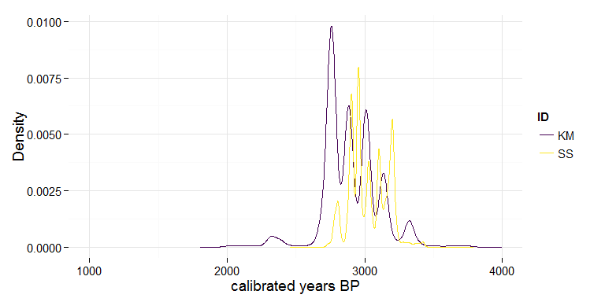

```r
library(ggplot2)
library(viridis)
ggplot(plot_all, aes(dateGrid, densFinal, colour = ID)) +
  geom_line(size = 0.5) +
  theme_minimal(base_size = 14) +
  xlab("calibrated years BP") +
  ylab("Density") +
  xlim(1000,4000) +
  scale_color_manual(values = viridis(length(unique(plot_all$ID))))
```

The table summarising counts and concentrations of residues in the samples

```r
# we follow the example of Copley, doi:10.1016/j.jas.2004.07.004
# read in data
CSIA_KM <- read.csv('data/CSIA_KM.csv', stringsAsFactors = FALSE)
CSIA_SS <- read.csv('data/CSIA_SS.csv', stringsAsFactors = FALSE)

site_names <- c("Kimpo-Yngchon", "Sosa-Dong")
containing_lipid_residues <- c(nrow(CSIA_KM), nrow(CSIA_SS))
total_sherds <- c(49, 37)
percentage_containing_lipid_residues <- round((containing_lipid_residues / total_sherds * 100), 0)
lipid_concentrations_ng_max <- c(max(CSIA_KM$Lipid.concentration..ng.g.1.),
                                 max(CSIA_SS$Lipid.concentration..ng.g.1.))
lipid_concentrations_ng_mean <- c(mean(CSIA_KM$Lipid.concentration..ng.g.1.),
                                  mean(CSIA_SS$Lipid.concentration..ng.g.1.))
lipid_concentrations_ug_max <-  round(lipid_concentrations_ng_max / 10e2, 3)
lipid_concentrations_ug_mean <- round(lipid_concentrations_ng_mean / 10e2, 3)

summary_table <- data.frame( total_sherds,
                             containing_lipid_residues,
                             percentage_containing_lipid_residues,
                             lipid_concentrations_ug_max,
                             lipid_concentrations_ug_mean)

# following the example in https://cran.r-project.org/web/packages/htmlTable/vignettes/tables.html
library(htmlTable)
htmlTable(summary_table,
          header = c("Total", "Containing lipid residues", "Percentage containing residues",
                     "Maximum", "Mean"),
          rnames = site_names,
          cgroup = c("Number of sherds", "", "Lipid concentrations (&mu;g g<sup>−1</sup>)"),
          n.cgroup = c(2, 1, 2),
          caption="Number of sherds containing lipids and their concentrations")
```

| Number of sherds containing lipids and their concentrations | Number of sherds containing lipids and their concentrations Number of sherds Total | Number of sherds containing lipids and their concentrations Number of sherds Containing lipid residues | Number of sherds containing lipids and their concentrations | Number of sherds containing lipids and their concentrations Percentage containing residues | Number of sherds containing lipids and their concentrations | Number of sherds containing lipids and their concentrations Lipid concentrations (μg g<sup>-1</sup>) Maximum | Number of sherds containing lipids and their concentrations Lipid concentrations (μg g<sup>-1</sup>) Mean |
| --- | --- | --- | --- | --- | --- | --- | --- |
| Kimpo-Yngchon | 49 | 20 |  | 41 |  | 262.741 | 101.497 |
| Sosa-Dong | 37 | 28 |  | 76 |  | 122.345 | 36.489 |

```r
# table of Potsherd number, Laboratory code,    Period, Wall, decoration, technique Diameter at mouth (cm), Part of vessel, Lipid concentration (μg g−1),   δ13C16.0,   δ13C18.0,   Δ13C following http://www.nature.com/nature/journal/v486/n7403/fig_tab/nature11186_T1.html
table_of_concs <- data.frame(rbind(
  with(CSIA_KM, cbind(Sample.No., C16.0, C18.0,  Lipid.concentration..ng.g.1.)),
  with(CSIA_SS, cbind(Sample.No., C16.0, C18.0,  Lipid.concentration..ng.g.1.))
), stringsAsFactors = FALSE)


# get sample location and body part
sampling_KM <- read.csv('data/sampling_Kimpo.csv', stringsAsFactors = FALSE)
sampling_SS <- read.csv('data/sampling_Sosa.csv', stringsAsFactors = FALSE)
table_of_samples <- data.frame(rbind(sampling_KM, sampling_SS))

# join concs to sample location and body part
table_of_details <- merge(table_of_samples, table_of_concs, by = 'Sample.No.')

# clean it a bit...
remove <- c("/", "No.")
table_of_details$Location.house.pit.No. <- gsub(paste(remove, collapse = "|"), "", table_of_details$Location.house.pit.No.)
table_of_details$Location.house.pit.No. <- gsub("  ", "", table_of_details$Location.house.pit.No.)

# make concs readable in ug/g and remove ng
table_of_details$Lipid.concentration..ug.g.1. <- sprintf("%.3f", as.numeric(as.character(table_of_details$Lipid.concentration..ng.g.1.)) / 10e2)
table_of_details$Lipid.concentration..ng.g.1. <- NULL

# add big delta
table_of_details$big_delta <- round(
                               as.numeric(as.character(table_of_details$C18.0)) -
                               as.numeric(as.character(table_of_details$C16.0)), 2)

# make readable column headings (use HTML codes for greeks)
names(table_of_details) <- c("Laboratory <br>code",
                             "Provenance",
                             "Part of <br>vessel",
                             paste0("&delta;","<sup>13</sup>C 16.0"),
                             paste0("&delta;","<sup>13</sup>C 18.0"),
                             "Lipid <br>concentration <br>(&mu;g g<sup>−1</sup>)",
                             "&Delta;<sup>13</sup>C")

library(htmlTable)
htmlTable(table_of_details,
          header = names(table_of_details),
          caption="Potsherds selected for isotopic analyses")
```

| Potsherds selected for isotopic analyses | Potsherds selected for isotopic analyses Laboratory code | Potsherds selected for isotopic analyses Provenance | Potsherds selected for isotopic analyses Part of vessel | Potsherds selected for isotopic analyses δ<sup>13</sup>C 16.0 | Potsherds selected for isotopic analyses δ<sup>13</sup>C 18.0 | Potsherds selected for isotopic analyses Lipid concentration (μg g<sup>-1</sup>) | Potsherds selected for isotopic analyses Δ<sup>13</sup>C |
| --- | --- | --- | --- | --- | --- | --- | --- |
| 1 | KIM038 | Area 2-3 Na 11 | Body | -29.6 | -31.2 | 44.239 | -1.6 |
| 2 | KIM042 | Area 2-1 L 10 | Rim | -28.8 | -27.3 | 36.314 | 1.5 |
| 3 | KIM043 | Area 2-1 L 10 | Body | -26.7 | -25.4 | 184.705 | 1.3 |
| 4 | KIM044 | Area 2-1 L 11 | Body | -25.6 | -26.2 | 39.649 | -0.6 |
| 5 | KIM049 | Area 2-1 D 14 | Body | -16.8 | -17.2 | 36.931 | -0.4 |
| 6 | KIM051 | Area 2-1 D 8 | Body | -27.8 | -27.7 | 69.862 | 0.1 |
| 7 | KIM052 | Area 2-1 D 8 | Body | -27.9 | -29.3 | 66.137 | -1.4 |
| 8 | KIM057 | Area 2-1 L 3 | Body | -24.8 | -22.5 | 204.225 | 2.3 |
| 9 | KIM059 | Area 2-3 NA 5 | Body | -27.3 | -27.7 | 105.160 | -0.4 |
| 10 | KIM060 | Area 2-3 NA 5 | Body | -26.7 | -24.7 | 171.533 | 2 |
| 11 | KIM061 | Area 2-1 G 3 | Body | -23 | -25.4 | 33.876 | -2.4 |
| 12 | KIM062 | Area 2-1 G 3 | Body | -27.8 | -26.9 | 59.818 | 0.9 |
| 13 | KIM069 | Area 2-4 Ra 20 | Body | -25.7 | -26.6 | 262.741 | -0.9 |
| 14 | KIM071 | Area 2-1 B-1 3 | Body | -28.7 | -29.8 | 63.481 | -1.1 |
| 15 | KIM072 | Area 2-1 D 14 | Body | -28.3 | -29.7 | 61.782 | -1.4 |
| 16 | KIM073 | Area 2-1 G 5 | Rim | -27.2 | -27.8 | 92.617 | -0.6 |
| 17 | KIM075 | Area 2-1 J 1 | Body | -24.1 | -23.5 | 185.697 | 0.6 |
| 18 | KIM076 | Area 2-1 L 1 | Body | -26.5 | -26.4 | 195.786 | 0.1 |
| 19 | KIM077 | Area 2-1 D 9 | Body | -27.3 | -27.5 | 82.557 | -0.2 |
| 20 | KIM078 | Area 2-1 L 9 | Rim | -21.8 | -24.7 | 32.820 | -2.9 |
| 21 | SOS030 | Area La14 | Body | -25.7 | -27.3 | 122.345 | -1.6 |
| 22 | SOS031 | Area La4 | Body | -26 | -27.9 | 119.377 | -1.9 |
| 23 | SOS032 | Area La4 | Rim | -23.8 | -25.7 | 37.920 | -1.9 |
| 24 | SOS033 | Area La4 | Rim | -22.8 | -31.1 | 19.835 | -8.3 |
| 25 | SOS035 | Area Ga10 | Body | -29.5 | -27.2 | 45.510 | 2.3 |
| 26 | SOS036 | Area Ga10 | Body | -22.8 | -24.5 | 24.399 | -1.7 |
| 27 | SOS037 | Area Ga14 | Body | -28.8 | -28.5 | 16.596 | 0.3 |
| 28 | SOS038 | Area Ga14 | Body | -26.5 | -24.3 | 29.610 | 2.2 |
| 29 | SOS039 | Area La11 | Rim | -30.7 | -28.1 | 31.824 | 2.6 |
| 30 | SOS040 | Area La11 | Body | -26.2 | -23.5 | 31.390 | 2.7 |
| 31 | SOS041 | Area La11 | Body | -26 | -23.6 | 37.127 | 2.4 |
| 32 | SOS042 | Area Ga23 | Body | -23.2 | -23.9 | 22.991 | -0.7 |
| 33 | SOS043 | Area Ga23 | Body | -26.8 | -26.3 | 16.033 | 0.5 |
| 34 | SOS045 | Area Ga24 | Body | -28.6 | -27.7 | 36.863 | 0.9 |
| 35 | SOS047 | Area Ga25 | Body | -29 | -27.5 | 27.686 | 1.5 |
| 36 | SOS048 | Area La15 | Rim | -26.1 | -23.9 | 24.800 | 2.2 |
| 37 | SOS049 | Area La15 | Rim | -27.4 | -24.3 | 30.106 | 3.1 |
| 38 | SOS050 | Area La15 | Rim | -27.9 | -23.6 | 23.529 | 4.3 |
| 39 | SOS051 | Area La2 | Body | -22.3 | -21.4 | 17.794 | 0.9 |
| 40 | SOS054 | Area La5 | Body | -25.2 | -25.7 | 28.775 | -0.5 |
| 41 | SOS055 | Area La10 | Body | -27.4 | -27.4 | 28.392 | 0 |
| 42 | SOS056 | Area La10 | Rim | -24.6 | -22.3 | 19.504 | 2.3 |
| 43 | SOS057 | Area La19 | Body | -25.4 | -23 | 34.896 | 2.4 |
| 44 | SOS058 | Area La19 | Body | -29 | -25 | 56.703 | 4 |
| 45 | SOS060 | Area La18 | Body | -25.8 | -24.2 | 29.385 | 1.6 |
| 46 | SOS062 | Area La31 | Body | -25.9 | -23.5 | 43.995 | 2.4 |
| 47 | SOS063 | Area La31 | Body | -25.3 | -23.1 | 45.240 | 2.2 |
| 48 | SOS064 | Area La32 | Body | -25.2 | -26.3 | 19.058 | -1.1 |

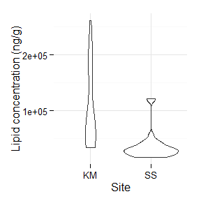

```r
# Is the recovery rate signficantly different?
# chi-square to test if recovery rate is different
# From Agresti(2007) p.39
M <- as.table(cbind((total_sherds - containing_lipid_residues),
                     containing_lipid_residues))
dimnames(M) <- list(site = c("KM", "SS"),
                    condition = c("not_containing","containing"))

chi_sq_M <- chisq.test(M, simulate.p.value = TRUE, B = 10000)
chi_sq_M_chivalue <- unname(round(chi_sq_M$statistic, 3))
chi_sq_M_pvalue <- round(chi_sq_M$p.value, 3)
chi_df <- (nrow(M)-1) * (ncol(M)-1)

# Are the concentrations of lipids different between the two sites?
concs <- stack(list(KM = CSIA_KM$Lipid.concentration..ng.g.1.,
                    SS = CSIA_SS$Lipid.concentration..ng.g.1.))
# plot
ggplot(concs, aes(y = values, x = ind)) +
  geom_violin() +
  ylab("Lipid concentration (ng/g)") +
  xlab("Site") +
  theme_minimal()
```

```r
# t-test
lipid_concentrations_diff <- t.test(CSIA_KM$Lipid.concentration..ng.g.1.,
                                    CSIA_SS$Lipid.concentration..ng.g.1.)
# test value
lipid_concentrations_diff_t <- unname(round(lipid_concentrations_diff$statistic, 3))
# p value
lipid_concentrations_diff_p <- unname(round(lipid_concentrations_diff$p.value, 3))
```

There is a difference in the recovery rate at the two sites (chi(1, n = 86) = 10.387, p = 0.002), with significantly more samples from Sosa-Dong containing residues. However, samples from Sosa-Dong have significantly lower concentrations per sherd than Kimpo-Yngchon (t(n = 48) = 3.899, p = 0.001).

The chromatogram of the GC-MS analysis from one of our samples from the Sosa-Dong site (SOS049). Due to degradation, we usually observe medium- and long-chain saturated fatty acids. 5-α Cholestane was added as an internal standard (132 ng / microliter).

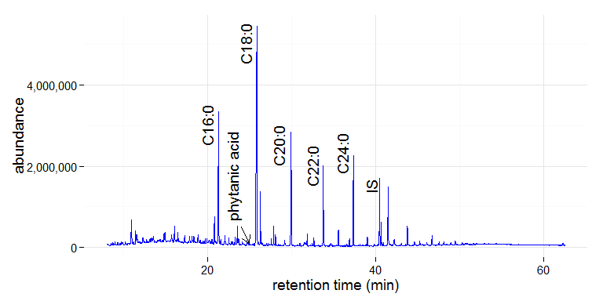

```r
# Input data from csv file
SOS049 <-  read.csv(file="data/GC-MS_exported_data_Figure5a.CSV", header=TRUE, sep=",")
make_retention_times_plot(SOS049)
```

The second chromatogram, sample KIM061

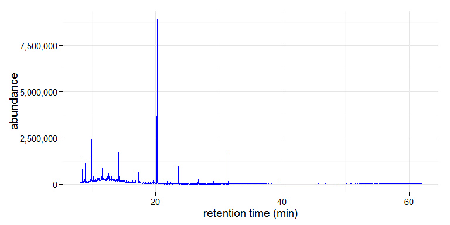

```r
# Input data from csv file
KIM061 <- read.csv(file="data/GC-MS_exported_data_Figure5b.CSV", header=TRUE, sep=",")
make_retention_times_plot_no_labels(KIM061)
```

The results of CSIA by GC-C-IRMS of the samples from the Sosa-Dong (SO) and Kimpo-Yangchon (KI) site using the reference from Craig et al., 2011 and Steele et al., 2010.

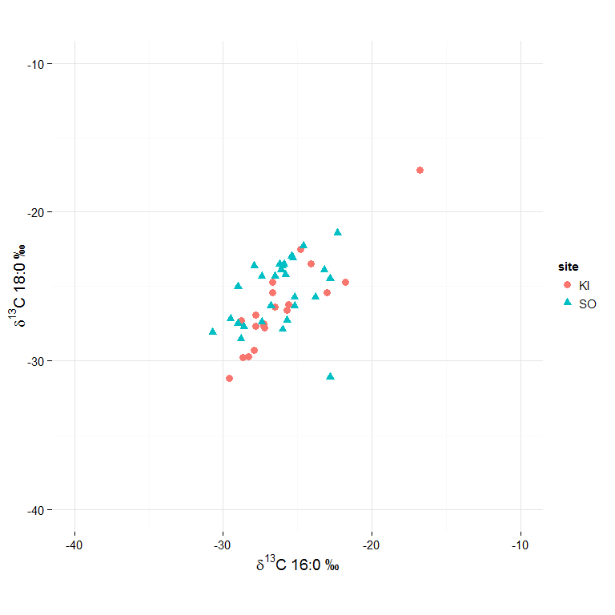

```r
# combine both into one dataframe
CSIA_KM_and_SS <- rbind(CSIA_KM, CSIA_SS)
# get site ID to control plotting colour and shape
CSIA_KM_and_SS$ID <- substr(CSIA_KM_and_SS$Sample.No., 1, 2)
# draw plot
make_C16_C18_scatter_plot(CSIA_KM_and_SS) # +
```

```r
   # geom_text(aes(label = Sample.No.), hjust = 0, vjust = 0)
```

The big delta plot

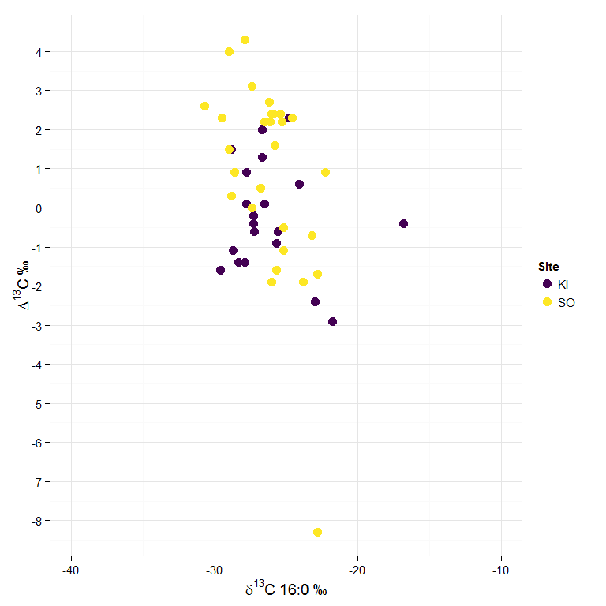

```r
# big_delta <- d18 - d16
big_delta <- CSIA_KM_and_SS$C18.0 - CSIA_KM_and_SS$C16.0
big_delta <- data.frame(big_delta = big_delta,
                        C16.0 = CSIA_KM_and_SS$C16.0,
                        Site = CSIA_KM_and_SS$ID,
                        sample_ID = CSIA_KM_and_SS$Sample.No.)
# plot
ggplot(big_delta, aes(C16.0, big_delta, colour = Site)) +
  geom_point(size = 4) +
  xlab(bquote(delta*{}^13*"C 16:0 \u2030")) +
  ylab(bquote(Delta*{}^13*"C \u2030")) +
  xlim(-40,-10) +
  theme_minimal(base_size = 14) +
  scale_y_continuous(breaks=seq(-10, 5, 1)) +
  scale_color_manual(values = viridis(length(unique(big_delta$Site)))) # +
```

```r
  # geom_text(aes(label = sample_ID), hjust = 0, vjust = 0)
  # SOS033 is the outlier at -8 Delta C18
```